# Practicals — Introduction to Bayesian analysis for medical studies — Solutions to exercise 1

Boris Hejblum

May 13<sup>th</sup> 2019

# Exercise 1: Monte Carlo

1. Create a Monte Carlo sample of size $50$ from a Gaussian distribution with mean $m=2$ and standard deviation $s=3$. Compute Monte Carlo estimates of both the mean and the standarddeviation on this $50$-sample. Then create a sample of size $20\,000$ and compute again such estimates on this $20\,000$-sample. What do you notice ? Which famous theoretical property is illustrated here ?

   ```r
   sample_50 <- rnorm(50, mean = 2, sd = 3)
   mean(sample_50)
   ```

   ```
   ## [1] 2.072603
   ```

   ```r
   sample_20000 <- rnorm(20000, mean = 2, sd = 3)
   mean(sample_20000)
   ```

   ```
   ## [1] 1.983059
   ```

   *When the sample size increase, the Monte Carlo estimator becomes more precise. This illustrate the Law of Large Numbers.*
2. Let’s now program an estimate of $\pi\approx 3,1416$
   1. Program a function `roulette_coord` which has only one argument `ngrid` (representing the number of different outcomes possible on the *roulette* used) whose default is `35`, generating the two coordinates of a point (between $0$ and $35$) as a vector. Use the `R` function `sample` (whhose help page is accessible through the command `?sample`). The function will return the vector of the 2 coordinates `x` and `y` generated this way.

      ```r
      roulette_coord <- function(ngrid = 35) {
          x <- sample(x = 0:ngrid, size = 1)
          y <- sample(x = 0:ngrid, size = 1)
          return(c(x, y))
      }
      ```

   2. Thanks to the formula to compute the distance bewteen 2 points: $d = \sqrt{(x_1 - x_2)^2 + (y_1 - y_2)^2}$, program a function computing the distance to the origin (here has coordinates $(\frac{ngrid}{2}, \frac{ngrid}{2})$) that checks if the computed distance is less than the unit disk radius ($R = \frac{ngrid}{2}$). This function, called for instance `inside_disk_fun()`, will have 2 arguments: the vector `p` containing the coordinates of the points on the one hand, and the integer `ngrid` on the other hand. It will return a boolean value (`TRUE`or `FALSE`) indicating the point is inside the disk.

      ```r
      inside_disk_fun <- function(p, ngrid = 35) {
          d <- sqrt((p[1] - ngrid/2)^2 + (p[2] - ngrid/2)^2)
          return(d <= ngrid/2)
      }
      ```

   3. The surface ratio between the disk (radius $\frac{ngrid}{2}$) and the square (side length $ngrid$) is equal to $\frac{\pi}{4}$, i.e. the probability of sampling a point the disk rather than outside is $\frac{\pi}{4}$. Now, using this result, program a function to compute a Monte Carlo estimate of $pi$ from a boolean vector of size $n$ (the number of sampled points), which is `TRUE` if the point is indeed inside the disk and `FALSE` otherwise.

      ```r
      piMC <- function(in_disk) {
          return(mean(4 * in_disk))
      }
      ```

   4. Using the code below, generate 200 points and plot the data generated. What is the corresponding Monte Carlo estimate of $\pi$ ? Change `npoints` and comment. How could the estimation be improved (ProTip: try `ngrid <- 1000` and `npoints <- 5000`) ?

      ```r
      # Grid size (resolution)
      ngrid <- 35

      # Monte Carlo sample size
      npoints <- 200

      # Points generation
      pp <- matrix(NA, ncol = 2, nrow = npoints)
      for (i in 1:nrow(pp)) {
          pp[i, ] <- roulette_coord(ngrid)
      }

      # Estimate pi
      in_disk <- apply(X = pp, MARGIN = 1, FUN = inside_disk_fun, ngrid = ngrid)
      piMC(in_disk)
      ```

      ```
      ## [1] 2.82
      ```

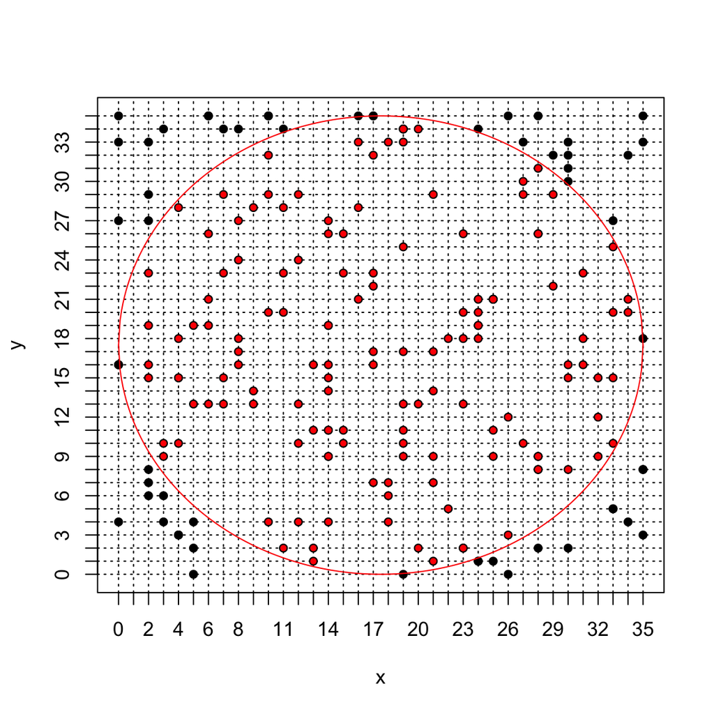

      ```r
      # Plot first we initialise an empty plot with the right size using argument
      plot(x = pp[, 1], y = pp[, 2], xlim = c(0, ngrid), ylim = c(0, ngrid), axes = 0,
          xlab = "x", ylab = "y", type = "n")
      ## we tick the x and then y axes from 1 to ngrid
      axis(1, at = c(0:ngrid))
      axis(2, at = c(0:ngrid))
      ## we add a square around the plot
      box()
      ## we plot the grid (using dotted lines thanks to the argument `lty = 3`)
      ## onto which the points are sample
      for (i in 0:ngrid) {
          abline(h = i, lty = 3)
          abline(v = i, lty = 3)
      }
      ## we add the sampled points
      lines(x = pp[, 1], y = pp[, 2], xlim = c(0, ngrid), ylim = c(0, ngrid), xlab = "x",
          ylab = "y", type = "p", pch = 16)
      ## we add the circle display
      x.cercle <- seq(0, ngrid, by = 0.1)
      y.cercle <- sqrt((ngrid/2)^2 - (x.cercle - ngrid/2)^2)
      lines(x.cercle, y = y.cercle + ngrid/2, col = "red")
      lines(x.cercle, y = -y.cercle + ngrid/2, col = "red")
      ## finally we color in red the points sampled inside the disk
      lines(x = pp[in_disk, 1], y = pp[in_disk, 2], xlim = c(0, ngrid), ylim = c(0,
          ngrid), xlab = "x", ylab = "y", type = "p", pch = 16, col = "red", cex = 0.7)
      ```

      *When the sample size increase, the Monte Carlo estimator becomes more precise (LLN). However, if the grid is too coarse, $\widehat{\pi}$ is underestimated (underestimating the disk surface by missing the bits near the edge). Therefore, increasing the number of points on the grid also improves the precision of the Monte Carlo.*